# 算法训练营Day 15

Author

Siru Wu

Published

February 2, 2026

## [110.平衡二叉树](https://leetcode.cn/problems/balanced-binary-tree/description/)

**平衡二叉树的定义：**

- 对于任意一个节点
- 左子树高度 − 右子树高度 的绝对值 ≤ 1
- 并且 **左右子树本身也必须是平衡的**

> 给定一个二叉树，判断它是否是 平衡二叉树

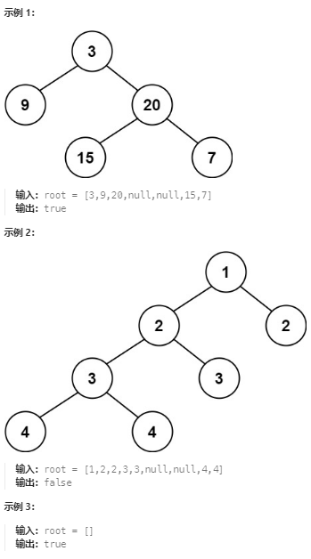

### 递归法

对这一段code的理解：

在二叉树里：

```
  A
 / \
B   C
```

A 是 父节点，B、C 是 子节点，这是一个数据结构关系

代码的执行流程是这样的：

get_height(A) ├─ 调用 get_height(B) │ ├─ 调用 get_height(None) │ ├─ 调用 get_height(None) │ └─ 执行 B 的 middle → return └─ 回到 get_height(A) ├─ 得到 left_height ├─ 调用 get_height(C) └─ 执行 A 的 middle

```python
# Definition for a binary tree node.
# class TreeNode:
#     def __init__(self, val=0, left=None, right=None):
#         self.val = val
#         self.left = left
#         self.right = right
class Solution:
    def isBalanced(self, root: Optional[TreeNode]) -> bool:
        if self.get_height(root) != -1:
            return True
        else:
            return False

    def get_height(self, root):
        if not root:
            return 0

        # 左
        if (left_height := self.get_height(root.left)) == -1:
            return -1

        # 右
        if (right_height := self.get_height(root.right)) == -1:
            return -1

        # 中
        if abs(left_height - right_height) > 1:
            return -1
        else:
            return 1 + max(left_height, right_height)
```

## [257. 二叉树的所有路径](https://leetcode.cn/problems/binary-tree-paths/description/)

> 给你一个二叉树的根节点 root ，按 任意顺序 ，返回所有从根节点到叶子节点的路径。

> 叶子节点 是指没有子节点的节点。

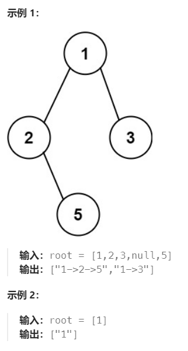

```python
# 回溯一定要配对, 进递归前 append, 出递归后 pop
class Solution:
  def traversal(self, cur, path, result):
    path.append(cur.val) # 这里要写cur.val
    if not cur.left and not cur.right:
      spath = '->'.join(map(str, path))
      result.append(spath)
      return

    if cur.left:
      self.traversal(cur.left, path, result)
      # 因为 path 是共享的, 所以必须回退一步，恢复到「没走左子树之前」的状态，这一步叫 回溯
      path.pop()

    if cur.right:
      self.traversal(cur.right, path, result)
      path.pop()

  def binaryTreePaths(self, root: Optional[TreeNode]) -> List[str]:
    result = []
    path = []
    if not root:
      return result
    self.traversal(root, path, result)
    return result
```

## [404.左叶子之和](https://leetcode.cn/problems/sum-of-left-leaves/description/)

> 给定二叉树的根节点 root ，返回所有左叶子之和。

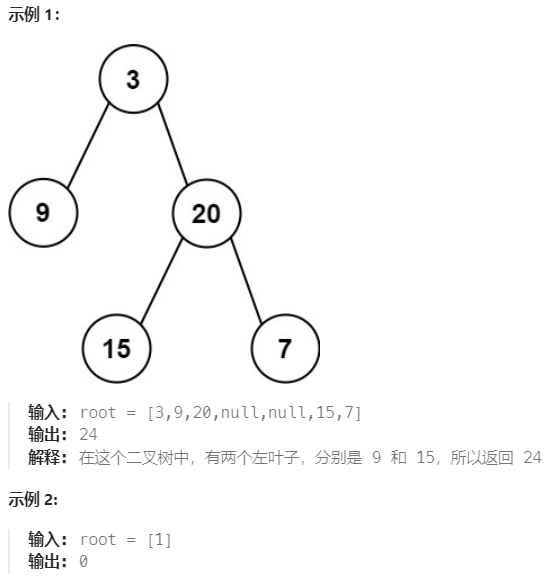

```python
# Definition for a binary tree node.
# class TreeNode:
#     def __init__(self, val=0, left=None, right=None):
#         self.val = val
#         self.left = left
#         self.right = right
class Solution:
    def sumOfLeftLeaves(self, root):
      if root is None:
        return 0
      if root.left is Non and root.right is None:
        return 0

      leftVal = self.sumOfLeftLeaves(root.left)
      rightVal = self.sumOfLeftLeaves(root.right)
      if root.left and root.left.left is None and root.left.right is None:
        leftVal = root.left.val

      sum_val = leftVal + rightVal
      return sum_val
```

## [222. 完全二叉树的节点个数](https://leetcode.cn/problems/count-complete-tree-nodes/description/)

> 给你一棵 完全二叉树 的根节点 root ，求出该树的节点个数。

> 完全二叉树 的定义如下：在完全二叉树中，除了最底层节点可能没填满外，其余每层节点数都达到最大值，并且最下面一层的节点都集中在该层最左边的若干位置。若最底层为第 h 层（从第 0 层开始），则该层包含 1~ 2h 个节点。

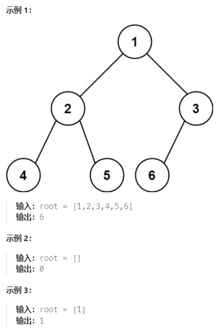

```python
class Solution:
    def countNodes(self, root: TreeNode) -> int:
      return self.getNodeNum(root)

    def getNodeNum(self, cur):
      if not cur:
        return 0

      leftNum = self.getNodeNum(cur.left)
      rightNum = self.getNodeNum(cur.right)
      totalNum = 1 + leftNum + rightNum
      return totalNum
```

```python
class Solution:
    def countNodes(self, root: TreeNode) -> int:
      if not root:
        return 0
      left = root.left
      right = root.right
      left_length = 0
      right_length = 0

      while left:
        left = left.left
        left_length += 1
      while right:
        right = right.right
        right_length += 1

      # 这个if在判断这个完全二叉树是不是满二叉树
      if left_length == right_length:
        return (2 ** (left_length + 1)) - 1

      return self.countNodes(root.left) + self.countNodes(root.right) + 1
```